# Actual Wrapped 2021 – 2025

A personal deep-dive into five years of Spotify listening history, moving beyond the canned Spotify Wrapped summary into **behavioural analysis** (themes, energy, skip patterns) and **predictive modelling** (can we predict whether a given play will be skipped?).

**Datasets** | file | rows | description | |---|---|---| | `dfSCleaned.csv` | ~55 k | Full play-by-play log, Nov-2021 → 2025 | | `df24.csv` | ~9.6 k | 2024 subset, enriched with `genre`, `energy`, `theme`, `language` |

**What this notebook covers**

1. Full-history EDA — top songs / artists / platforms / geography
2. 2024 deep-dive — theme & energy distributions
3. Theme & genre trends over time
4. Skip-behaviour analysis
5. Skip-prediction models (Random Forest → XGBoost → LightGBM → Ensemble)
6. Model evaluation (ROC, SHAP, cross-validation)
7. Causal structure (DAG) of the feature space

> **Reproducibility note.** The notebook reads data from `./` by default; override with the `SPOTIFY_DATA_DIR` environment variable.

```python
import os
from pathlib import Path
import numpy as np
import pandas as pd
import matplotlib.pyplot as plt
import plotly.express as px
```

## 1. Setup & Data Loading

```python
DATA_DIR = Path(os.environ.get('SPOTIFY_DATA_DIR', '.'))

dfS = pd.read_csv(DATA_DIR / 'dfSCleaned.csv')   # full 2021-2025 dataset
dfAn = pd.read_csv(DATA_DIR / 'df24.csv')        # 2024-only enriched dataset

# Normalise date columns up-front so downstream groupers work consistently
dfS['date'] = pd.to_datetime(dfS['date'], errors='coerce')
dfAn['date'] = pd.to_datetime(dfAn['date'], errors='coerce')

# drop the stray 'Unnamed: 0' index column if present
dfAn = dfAn.drop(columns=[c for c in dfAn.columns if c.startswith('Unnamed')], errors='ignore')

print(f'dfS:  {dfS.shape[0]:,} rows  |  {dfS.shape[1]} cols  |  {dfS["date"].min().date()} → {dfS["date"].max().date()}')
print(f'dfAn: {dfAn.shape[0]:,} rows  |  {dfAn.shape[1]} cols  |  {dfAn["date"].min().date()} → {dfAn["date"].max().date()}')
```

```
dfS:  55,392 rows  |  15 cols  |  2021-11-01 → 2025-01-14
dfAn: 9,594 rows  |  20 cols  |  2024-01-01 → 2024-12-31
```

## 2. Full-History EDA (2021 – 2025)

Top plays, top artists, and overall listening volume across the entire dataset.

```python
# Group by spotifyID, count occurrences, and sort by count in descending order
top_200_songs = (
    dfS.groupby(['spotifyID', 'track_name', 'artist_name'])  # Group by spotifyID, track_name, artist_name
    .size()  # Count occurrences
    .reset_index(name='count')  # Create a 'count' column
    .sort_values(by='count', ascending=False)  # Sort by count in descending order
    .head(200)  # Take the top 50 rows
)

# Now top_50_df is a DataFrame containing the top 50 rows
top_200_songs
```

|  | spotifyID | track_name | artist_name | count |
| --- | --- | --- | --- | --- |
| 5340 | 3fpl1wp5GcuomLNPiLwgcH | 1NIGHT - Maazel & Jupom Remix | yetep | 218 |
| 4197 | 2rOfnCrbxZpMvENtx8LqY9 | Gravity | yetep | 204 |
| 4327 | 2wn0zWnPeDnlY7Ue0i0OnR | Into My Heart (feat. GLNNA) | yetep | 157 |
| 5920 | 4548LyFomXQmDAINcFizEq | Learn To Love Again | Audien | 147 |
| 2978 | 21kVD9H40rRQkGmcMi01Fl | First Place | yetep | 145 |
| ... | ... | ... | ... | ... |
| 10777 | 7g7w1Xs3cZehtN1e0kUnSo | A Way To Say Goodbye - Ricky Mears Remix | Seven Lions | 53 |
| 11149 | 7vWFaMq63AwkFDhS2OAg5u | The Time (Dirty Bit) | Black Eyed Peas | 52 |
| 8720 | 60lVHKWmvmsJlv14Xw0mdO | Divine | ZEXTONE | 52 |
| 7648 | 5FvGI8KtImlEbOsvEW3pfX | The Fall | The Chainsmokers | 52 |
| 2044 | 1OEmd2iXU8pWG7CrKNpGUg | Humdard | Arijit Singh | 52 |

200 rows × 4 columns

```python
# Group by artist_name and count occurrences
top_50_artists = (
    dfS.groupby('artist_name')  # Group by artist_name
    .agg(
        playCount=('spotifyID', 'count'),  # Total count of spotifyIDs
        numofSongs=('spotifyID', 'nunique')  # Unique count of spotifyIDs
    )
    .reset_index()  # Reset index to get a flat DataFrame
    .sort_values(by='playCount', ascending=False)  # Sort by total count in descending order
    .head(50)  # Select the top 50 artists
)

# Display the top artists with their counts
top_50_artists
```

|  | artist_name | playCount | numofSongs |
| --- | --- | --- | --- |
| 3536 | yetep | 2070 | 76 |
| 422 | Big Sean | 1345 | 116 |
| 1295 | ILLENIUM | 1189 | 133 |
| 2455 | Pritam | 1181 | 132 |
| 254 | Arijit Singh | 1160 | 94 |
| 74 | ASMR Glow | 899 | 307 |
| 2761 | Seven Lions | 824 | 77 |
| 1978 | Maroon 5 | 743 | 56 |
| 536 | Calvin Harris | 670 | 75 |
| 301 | Audien | 666 | 44 |
| 1412 | Jason Derulo | 639 | 23 |
| 109 | Adele | 608 | 38 |
| 1089 | Future | 602 | 82 |
| 2651 | SLANDER | 594 | 52 |
| 854 | Drake | 579 | 105 |
| 3373 | Zedd | 516 | 40 |
| 65 | ARMNHMR | 509 | 51 |
| 2106 | Morgan Wallen | 463 | 36 |
| 3032 | The Chainsmokers | 455 | 44 |
| 119 | Adventure Club | 453 | 42 |
| 3002 | Taylor Swift | 414 | 88 |
| 1980 | Marshmello | 399 | 47 |
| 19 | 3LAU | 389 | 17 |
| 1048 | Flux Pavilion | 381 | 26 |
| 749 | Darshan Raval | 373 | 38 |
| 2162 | NOTD | 365 | 28 |
| 3288 | William Black | 346 | 51 |
| 974 | Excision | 338 | 42 |
| 2072 | Mithoon | 329 | 25 |
| 509 | Bullet For My Valentine | 321 | 27 |
| 1185 | Gryffin | 317 | 49 |
| 2135 | My Darkest Days | 315 | 18 |
| 760 | David Guetta | 305 | 35 |
| 1597 | Katy Perry | 301 | 31 |
| 3079 | The Weeknd | 287 | 56 |
| 2167 | NURKO | 275 | 37 |
| 650 | Cole Plante | 263 | 5 |
| 1414 | Jason Ross | 256 | 27 |
| 3171 | Tyga | 253 | 37 |
| 134 | Ajja | 237 | 36 |
| 517 | CHASE WRIGHT | 235 | 16 |
| 727 | Dan + Shay | 233 | 25 |
| 3109 | Tiësto | 215 | 27 |
| 2639 | SABAI | 207 | 27 |
| 1141 | GhostDragon | 203 | 25 |
| 721 | Dabin | 201 | 45 |
| 674 | Crystal Skies | 194 | 26 |
| 1785 | Lil Baby | 189 | 14 |
| 1982 | Martin Garrix | 189 | 24 |
| 3527 | tyDi | 189 | 7 |

```python
# Build the daily ms_played aggregate the chart expects
ms_played = (
    dfS.groupby('date')['ms_played']
       .sum()
       .reset_index(name='daily_ms')
)
ms_played['hours_played'] = ms_played['daily_ms'] / 3_600_000
average_hours_played = ms_played['hours_played'].mean()

# Interactive daily-hours line chart with an average reference line
fig = px.line(
    ms_played,
    x='date', y='hours_played',
    title='Daily Aggregation of Hours Played with Interactive Average Line',
    labels={'date': 'Date', 'hours_played': 'Hours Played'},
)
fig.add_scatter(
    x=[ms_played['date'].min(), ms_played['date'].max()],
    y=[average_hours_played, average_hours_played],
    mode='lines',
    line=dict(color='red', width=2, dash='dash'),
    name=f'Average: {average_hours_played:.2f} hours',
)
fig.update_xaxes(
    rangeslider_visible=True,
    rangeselector=dict(buttons=[
        dict(count=1, label='1m', step='month', stepmode='backward'),
        dict(count=6, label='6m', step='month', stepmode='backward'),
        dict(count=1, label='1y', step='year', stepmode='backward'),
        dict(step='all'),
    ]),
)
fig.update_layout(legend=dict(title='Legend', orientation='v', x=1.02, y=1, xanchor='left', yanchor='top'))
fig.show()
```

[interactive chart not shown]

```python
# Group the data by date and platform to calculate daily totals
daily_streamed = (
    dfS.groupby(pd.to_datetime(dfS['date'], errors='coerce'))['ms_played']
    .sum()
    .reset_index(name='daily_ms_played')
)

# Convert milliseconds to hours
daily_streamed['daily_hours_played'] = daily_streamed['daily_ms_played'] / 3_600_000

# Create a histogram for daily hours played with bins starting at 0
fig = px.histogram(
    daily_streamed,
    x='daily_hours_played',
    nbins=24,  # Create bins for each hour
    title='Histogram of Daily Hours Played',
    labels={'daily_hours_played': 'Daily Hours Played'},
    marginal='box',  # Optional: add a box plot on top for summary statistics
    range_x=[0, daily_streamed['daily_hours_played'].max()]  # Ensure bins start at 0
)

# Customize layout for better readability
fig.update_layout(
    xaxis_title='Daily Hours Played',
    yaxis_title='Frequency',
    title_x=0.5  # Center the title
)

# Show the plot
fig.show()
```

[interactive chart not shown]

### Platform & Geography

Where and how the listening happened.

```python
platform_counts = dfS['platform'].value_counts().reset_index()
platform_counts.columns = ['platform', 'count']

platform_counts
```

|  | platform | count |
| --- | --- | --- |
| 0 | ios | 47591 |
| 1 | osx | 5603 |
| 2 | not_applicable | 1298 |
| 3 | android | 900 |

```python
# Count occurrences of each distinct conn_country
country_counts = dfS['conn_country'].value_counts().reset_index()
country_counts.columns = ['conn_country', 'count']

# Display the result
country_counts
```

|  | conn_country | count |
| --- | --- | --- |
| 0 | US | 54432 |
| 1 | IN | 891 |
| 2 | DO | 69 |

## 3. 2024 Deep-Dive

Everything past this point uses the enriched 2024 dataset (`dfAn`), which adds `genre`, `energy`, `theme`, and `language` columns produced by a separate labelling pipeline.

```python
# Group the data by date and platform to calculate daily totals
daily_streamed = (
    dfAn.groupby([pd.to_datetime(dfAn['date'], errors='coerce'), 'platform'])['ms_played']
    .sum()
    .reset_index(name='daily_ms_played')
)

# Convert milliseconds to hours
daily_streamed['daily_hours_played'] = daily_streamed['daily_ms_played'] / 3_600_000

# Create a box plot grouped by platform
fig = px.box(
    daily_streamed,
    x='platform',
    y='daily_hours_played',
    title='Daily Total of Music Streamed by Platform (in Hours)',
    labels={'platform': 'Platform', 'daily_hours_played': 'Daily Hours Played'},
    points='all'  # Show all data points (jittered) on the plot
)

# Customize layout for better readability
fig.update_layout(
    xaxis_title='Platform',
    yaxis_title='Daily Hours Played',
    boxmode='group',  # Group by platform
    title_x=0.5  # Center the title
)

# Show the plot
fig.show()
```

[interactive chart not shown]

### Theme Distribution

The `theme` column is a coarse mood label (Romantic, Empowered, Hopeful, …). How often does each appear?

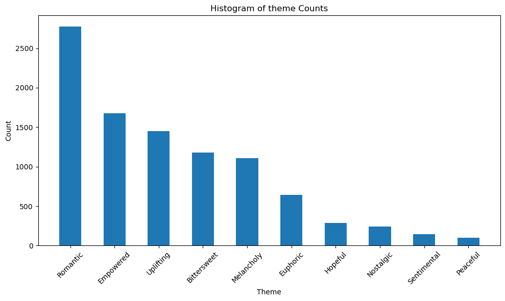

```python
# Count the occurrences of each theme
theme_counts = dfAn['theme'].value_counts()

# Create a histogram
plt.figure(figsize=(10, 6))
plt.bar(theme_counts.index, theme_counts.values, width=0.5)

# Customize the plot
plt.title('Histogram of theme Counts')
plt.xlabel('Theme')
plt.ylabel('Count')
plt.xticks(rotation=45)  # Rotate x-axis labels for better readability
plt.tight_layout()

# Show the plot
plt.show()
```

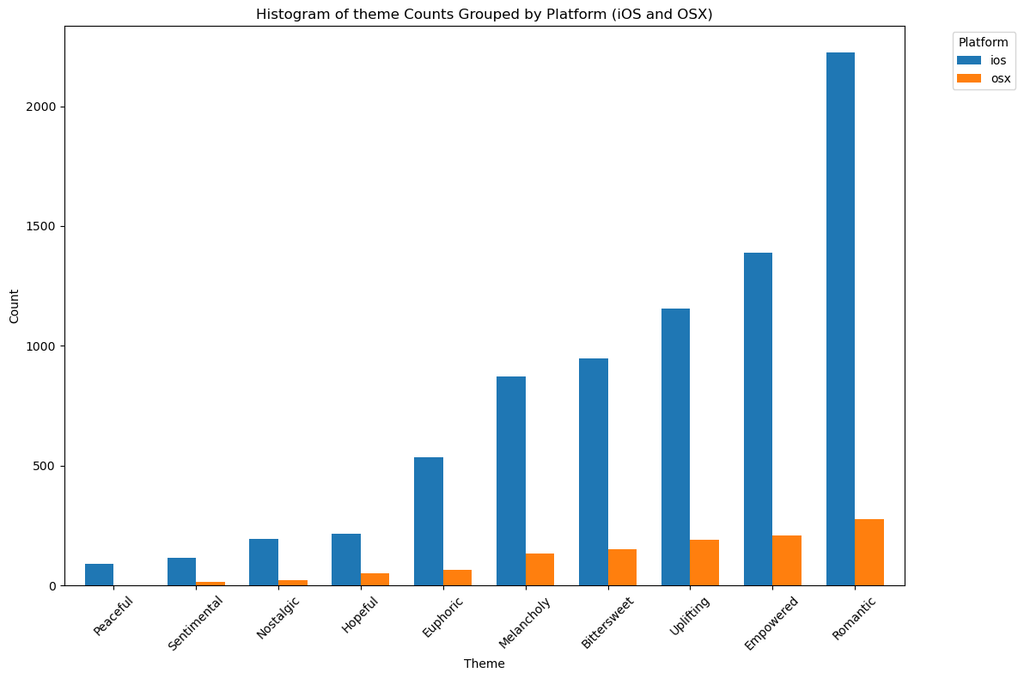

```python
import matplotlib.pyplot as plt

# Filter the data to only include 'ios' and 'osx'
dfAn_filtered = dfAn[dfAn['platform'].isin(['ios', 'osx'])]

# Group by platform and theme, then count occurrences
grouped_themes_filtered = dfAn_filtered.groupby(['platform', 'theme']).size().reset_index(name='count')

# Pivot the data for plotting
pivot_themes_filtered = grouped_themes_filtered.pivot(index='theme', columns='platform', values='count').fillna(0)

# Sort the pivot table by the 'ios' column in ascending order
pivot_themes_filtered = pivot_themes_filtered.sort_values(by='ios', ascending=True)

# Plot the histogram
pivot_themes_filtered.plot(kind='bar', figsize=(12, 8), width=0.7)

# Customize the plot
plt.title('Histogram of theme Counts Grouped by Platform (iOS and OSX)')
plt.xlabel('Theme')
plt.ylabel('Count')
plt.xticks(rotation=45)  # Rotate x-axis labels for better readability
plt.legend(title='Platform', bbox_to_anchor=(1.05, 1), loc='upper left')
plt.tight_layout()

# Show the plot
plt.show()
```

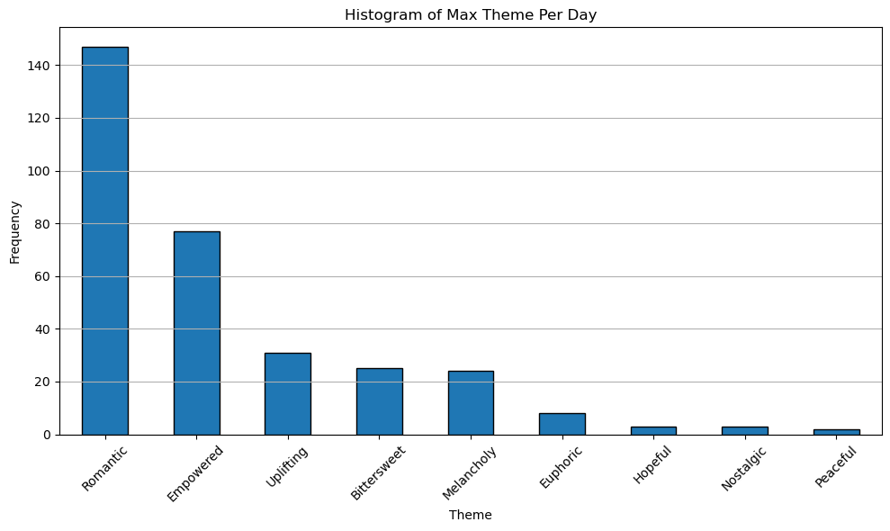

```python
# Group by date and find the mode (most frequent theme) per day
max_theme_per_day = dfAn.groupby('date')['theme'].agg(lambda x: x.mode()[0])

# Plot histogram of the max theme per day
plt.figure(figsize=(10, 6))
max_theme_per_day.value_counts().plot(kind='bar', edgecolor='black')
plt.title('Histogram of Max Theme Per Day')
plt.xlabel('Theme')
plt.ylabel('Frequency')
plt.grid(axis='y')
plt.xticks(rotation=45)  # Rotate x-axis labels for better readability
plt.tight_layout()
plt.show()
```

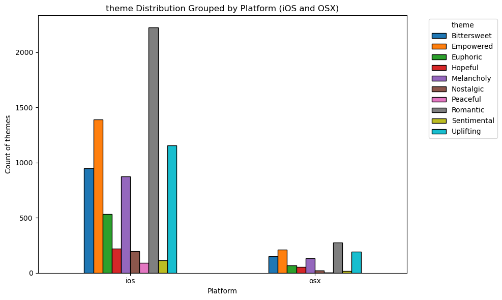

```python
# Filter data for ios and osx platforms
grouped_data = dfAn[dfAn['platform'].isin(['ios', 'osx'])].groupby(['platform', 'theme']).size().unstack()

# Plotting the double bar graph
grouped_data.plot(kind='bar', figsize=(10, 6), edgecolor='black')
plt.title('theme Distribution Grouped by Platform (iOS and OSX)')
plt.xlabel('Platform')
plt.ylabel('Count of themes')
plt.xticks(rotation=0)
plt.legend(title='theme', bbox_to_anchor=(1.05, 1), loc='upper left')
plt.tight_layout()
plt.show()
```

### Theme × Energy

Order themes by their average `energy` score — lowest to highest — so later plots can use a consistent theme-to-colour mapping.

```python
# Calculate the average energy level for each theme
theme_avg_energy = dfAn.groupby('theme')['energy'].mean()

# Sort themes by average energy level (highest to lowest)
theme_order = theme_avg_energy.sort_values(ascending=True).index

theme_order
```

```
Index(['Peaceful', 'Romantic', 'Bittersweet', 'Sentimental', 'Melancholy',
       'Hopeful', 'Nostalgic', 'Uplifting', 'Empowered', 'Euphoric'],
      dtype='object', name='theme')
```

```python
# Convert 'time' column to time type
dfAn['time'] = pd.to_datetime(dfAn['time'], format='%H:%M:%S').dt.time

# Display the updated dataframe info to confirm the change
print("Updated Dataframe with 'time' as time type:")
print(dfAn.info())
```

```
Updated Dataframe with 'time' as time type:
<class 'pandas.core.frame.DataFrame'>
RangeIndex: 9594 entries, 0 to 9593
Data columns (total 20 columns):
 #   Column          Non-Null Count  Dtype
---  ------          --------------  -----
 0   date            9594 non-null   datetime64[ns]
 1   time            9594 non-null   object
 2   conn_country    9594 non-null   object
 3   platform        9594 non-null   object
 4   track_name      9594 non-null   object
 5   artist_name     9594 non-null   object
 6   album_name      9594 non-null   object
 7   ms_played       9594 non-null   int64
 8   spotifyID       9594 non-null   object
 9   reason_start    9594 non-null   object
 10  reason_end      9594 non-null   object
 11  shuffle         9594 non-null   bool
 12  skipped         9594 non-null   bool
 13  offline         9594 non-null   bool
 14  incognito_mode  9594 non-null   bool
 15  play_count      9594 non-null   int64
 16  genre           9594 non-null   object
 17  energy          9594 non-null   float64
 18  theme           9594 non-null   object
 19  language        9586 non-null   object
dtypes: bool(4), datetime64[ns](1), float64(1), int64(2), object(12)
memory usage: 1.2+ MB
None
```

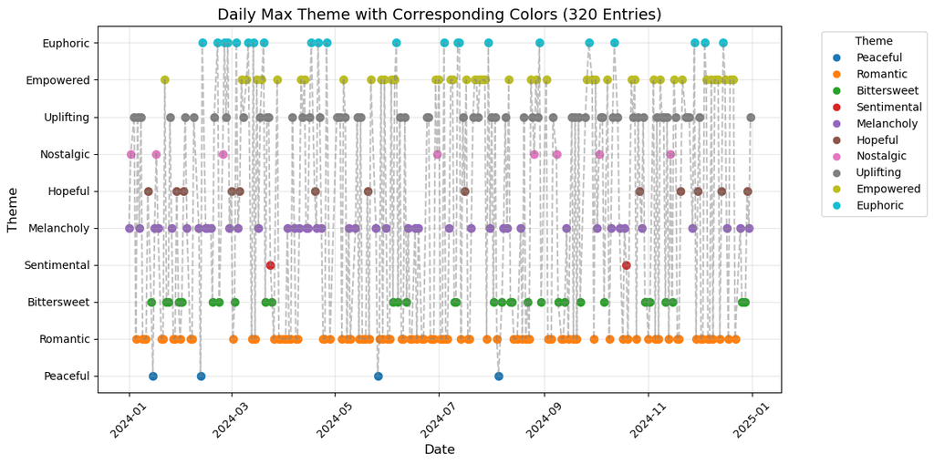

```python
# Build the daily-max-theme series (the dominant theme per day by ms_played)
_daily_max_theme_full = (
    dfAn.loc[dfAn.groupby('date')['ms_played'].idxmax()]
        .set_index('date')['theme']
)
filtered_daily_max_theme = _daily_max_theme_full  # kept as a Series indexed by date

# Assign a stable colour per theme based on theme_order (lowest→highest avg energy)
_palette = plt.cm.tab10.colors
theme_colors = {theme: _palette[i % 10] for i, theme in enumerate(theme_order)}

# Map themes to numeric values based on theme_order
theme_to_num = {theme: i for i, theme in enumerate(theme_order)}
num_to_theme = {i: theme for theme, i in theme_to_num.items()}

numeric_theme_values = filtered_daily_max_theme.map(theme_to_num).dropna()

plt.figure(figsize=(12, 6))
plt.plot(numeric_theme_values.index, numeric_theme_values, color='gray', alpha=0.5, linestyle='--', label='Trend Line')
for date, num in numeric_theme_values.items():
    plt.scatter(date, num, color=theme_colors[num_to_theme[num]], s=50)

handles = [plt.Line2D([0], [0], marker='o', color=theme_colors[theme], label=theme, linestyle='None')
           for theme in theme_order]
plt.legend(handles=handles, title='Theme', bbox_to_anchor=(1.05, 1), loc='upper left')

plt.title(f'Daily Max Theme with Corresponding Colors ({len(numeric_theme_values)} Entries)', fontsize=14)
plt.xlabel('Date', fontsize=12)
plt.ylabel('Theme', fontsize=12)
plt.xticks(rotation=45)
plt.yticks(range(len(theme_order)), theme_order)
plt.grid(alpha=0.3)
plt.tight_layout()
plt.show()
```

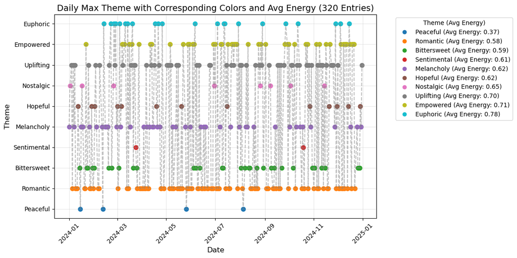

```python
# Extend the cell-22 chart with each theme's average energy in the legend
average_energy = dfAn.groupby('theme')['energy'].mean()

numeric_theme_values = filtered_daily_max_theme.map(theme_to_num).dropna()

plt.figure(figsize=(12, 6))
plt.plot(numeric_theme_values.index, numeric_theme_values, color='gray', alpha=0.5, linestyle='--', label='Trend Line')
for date, num in numeric_theme_values.items():
    plt.scatter(date, num, color=theme_colors[num_to_theme[num]], s=50)

handles = [
    plt.Line2D([0], [0], marker='o', color=theme_colors[theme],
               label=f"{theme} (Avg Energy: {average_energy[theme]:.2f})", linestyle='None')
    for theme in theme_order
]
plt.legend(handles=handles, title='Theme (Avg Energy)', bbox_to_anchor=(1.05, 1), loc='upper left')

plt.title(f'Daily Max Theme with Corresponding Colors and Avg Energy ({len(numeric_theme_values)} Entries)', fontsize=14)
plt.xlabel('Date', fontsize=12)
plt.ylabel('Theme', fontsize=12)
plt.xticks(rotation=45)
plt.yticks(range(len(theme_order)), theme_order)
plt.grid(alpha=0.3)
plt.tight_layout()
plt.show()
```

## 4. Theme Trends Over Time

For each week (and each day), find the theme that dominated total play-time, then regress play-time against time to see which themes are trending up or down.

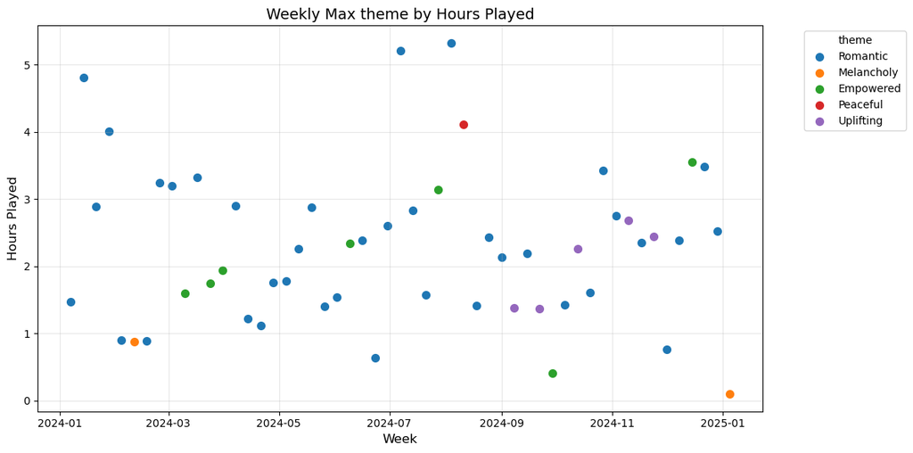

```python
# Ensure 'date' column is in datetime format
dfAn['date'] = pd.to_datetime(dfAn['date'])

# Resample the data to weekly and sum the ms_played for each theme
weekly_data = dfAn.groupby([pd.Grouper(key='date', freq='W'), 'theme'])['ms_played'].sum().reset_index()

# Find the theme with the maximum ms_played each week
weekly_max_theme = weekly_data.loc[weekly_data.groupby('date')['ms_played'].idxmax()].reset_index(drop=True)

# Generate a color palette for 10 different colors
color_palette = plt.cm.tab10.colors

# Assign a color to each theme
theme_colors = {theme: color_palette[i % 10] for i, theme in enumerate(weekly_max_theme['theme'].unique())}

# Convert ms_played to hours
weekly_data['ms_played'] = weekly_data['ms_played'] / 3600000
weekly_max_theme['ms_played'] = weekly_max_theme['ms_played'] / 3600000

# Plot the time series with colors based on max theme
plt.figure(figsize=(12, 6))
for i, row in weekly_max_theme.iterrows():
    plt.scatter(row['date'], row['ms_played'], color=theme_colors[row['theme']],
                label=row['theme'] if row['theme'] not in plt.gca().get_legend_handles_labels()[1] else "", s=50)

plt.title("Weekly Max theme by Hours Played", fontsize=14)
plt.xlabel("Week", fontsize=12)
plt.ylabel("Hours Played", fontsize=12)
plt.legend(title="theme", bbox_to_anchor=(1.05, 1), loc='upper left')
plt.grid(alpha=0.3)
plt.tight_layout()
plt.show()
```

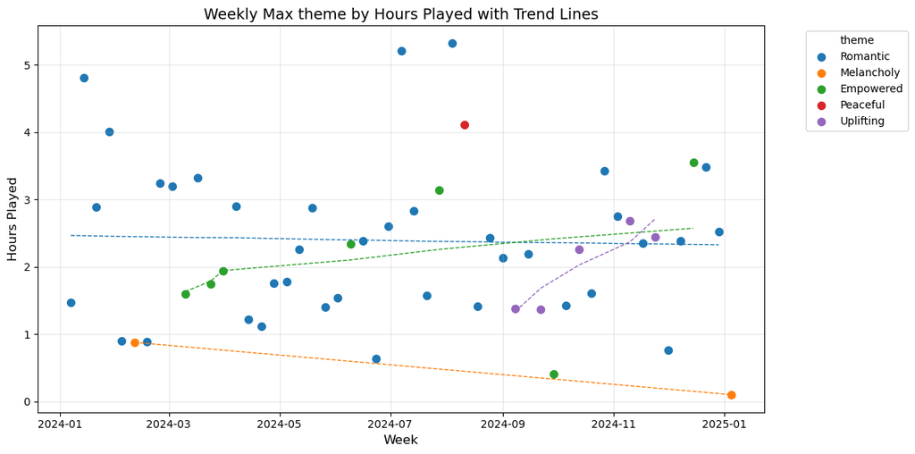

```python
from scipy.stats import linregress
import numpy as np

# Convert ms_played to hours


# Prepare the plot
plt.figure(figsize=(12, 6))

# Add scatter plot and trend lines for each theme
for theme in weekly_max_theme['theme'].unique():
    theme_data = weekly_max_theme[weekly_max_theme['theme'] == theme]

    # Scatter plot for the theme
    plt.scatter(theme_data['date'], theme_data['ms_played'],
                color=theme_colors[theme], label=theme, s=50)

    # Linear regression for the trend line
    x = np.arange(len(theme_data['date']))  # Use index for regression
    y = theme_data['ms_played']
    slope, intercept, _, _, _ = linregress(x, y)
    trend_line = slope * x + intercept

    # Plot the trend line
    plt.plot(theme_data['date'], trend_line,
             color=theme_colors[theme], linestyle='--', linewidth=1)

# Add titles and labels
plt.title("Weekly Max theme by Hours Played with Trend Lines", fontsize=14)
plt.xlabel("Week", fontsize=12)
plt.ylabel("Hours Played", fontsize=12)
plt.legend(title="theme", bbox_to_anchor=(1.05, 1), loc='upper left')
plt.grid(alpha=0.3)
plt.tight_layout()
plt.show()
```

```
Not enough data points for regression on theme: Peaceful
```

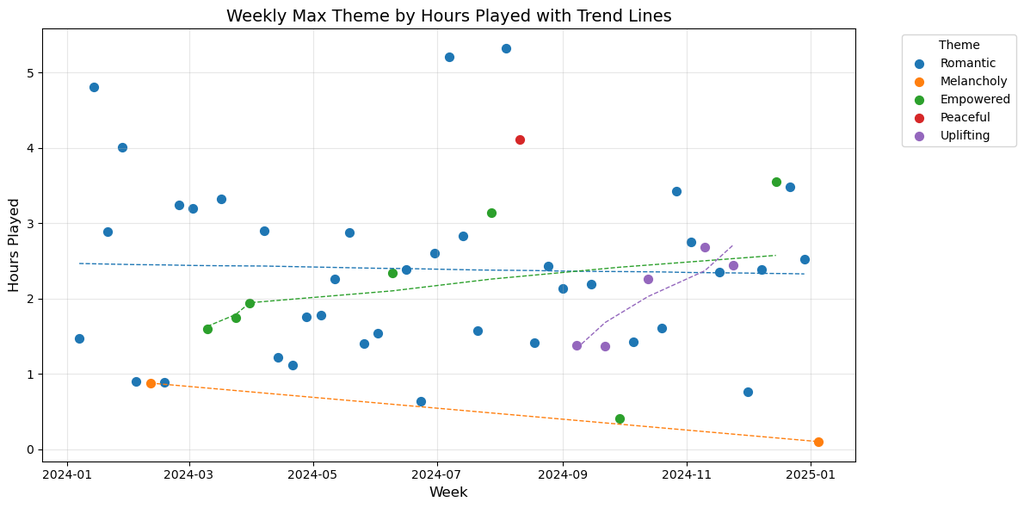

```python
# Weekly max-theme trend lines per theme (ms_played already in hours from the previous cell)
plt.figure(figsize=(12, 6))

for theme in weekly_max_theme['theme'].unique():
    theme_data = weekly_max_theme[weekly_max_theme['theme'] == theme].dropna(subset=['ms_played', 'date'])

    plt.scatter(theme_data['date'], theme_data['ms_played'],
                color=theme_colors.get(theme, 'gray'), label=theme, s=50)

    x = np.arange(len(theme_data))
    y = theme_data['ms_played'].values
    if len(x) > 1:
        from scipy.stats import linregress
        slope, intercept, *_ = linregress(x, y)
        plt.plot(theme_data['date'], slope * x + intercept,
                 color=theme_colors.get(theme, 'gray'), linestyle='--', linewidth=1)
    else:
        print(f'Not enough data points for regression on theme: {theme}')

plt.title('Weekly Max Theme by Hours Played with Trend Lines', fontsize=14)
plt.xlabel('Week', fontsize=12)
plt.ylabel('Hours Played', fontsize=12)
plt.legend(title='Theme', bbox_to_anchor=(1.05, 1), loc='upper left')
plt.grid(alpha=0.3)
plt.tight_layout()
plt.show()
```

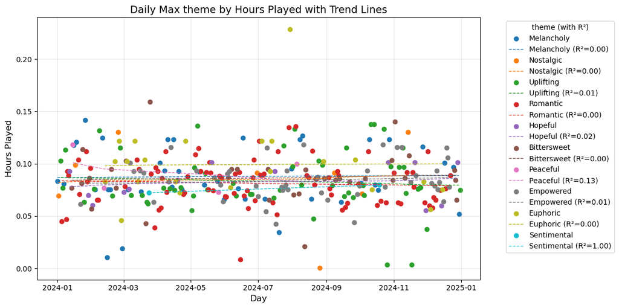

```python
daily_max_theme = dfAn.loc[dfAn.groupby('date')['ms_played'].idxmax()].reset_index(drop=True)
daily_max_theme['ms_played'] = daily_max_theme['ms_played'] / 3600000  # Convert ms to hours

# Generate or update color palette for all themes
color_palette = plt.cm.tab10.colors
theme_colors = {theme: color_palette[i % 10] for i, theme in enumerate(daily_max_theme['theme'].unique())}

# Prepare the plot
plt.figure(figsize=(12, 6))

# Add scatter plot and trend lines for each theme
for theme in daily_max_theme['theme'].unique():
    theme_data = daily_max_theme[daily_max_theme['theme'] == theme]

    # Assign a color if it's not in the theme_colors dictionary
    if theme not in theme_colors:
        theme_colors[theme] = color_palette[len(theme_colors) % 10]

    # Scatter plot for the theme
    plt.scatter(theme_data['date'], theme_data['ms_played'],
                color=theme_colors[theme], label=theme)

    # Linear regression for the trend line
    x = np.arange(len(theme_data['date']))  # Use index for regression
    y = theme_data['ms_played']
    slope, intercept, r_value, _, _ = linregress(x, y)
    trend_line = slope * x + intercept

    # Plot the trend line
    plt.plot(theme_data['date'], trend_line,
             color=theme_colors[theme], linestyle='--', linewidth=1,
             label=f"{theme} (R²={r_value**2:.2f})")

# Add titles and labels
plt.title("Daily Max theme by Hours Played with Trend Lines", fontsize=14)
plt.xlabel("Day", fontsize=12)
plt.ylabel("Hours Played", fontsize=12)
plt.legend(title="theme (with R²)", bbox_to_anchor=(1.05, 1), loc='upper left')
plt.grid(alpha=0.3)
plt.tight_layout()
plt.show()
```

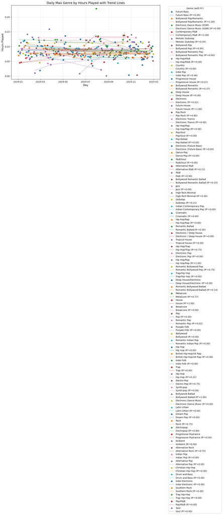

```python
daily_max_genre = dfAn.loc[dfAn.groupby('date')['ms_played'].idxmax()].reset_index(drop=True)
daily_max_genre['ms_played'] = daily_max_genre['ms_played'] / 3600000  # Convert ms to hours

# Generate or update color palette for all genres
color_palette = plt.cm.tab10.colors
genre_colors = {genre: color_palette[i % 10] for i, genre in enumerate(daily_max_genre['genre'].unique())}

# Prepare the plot
plt.figure(figsize=(12, 6))

# Add scatter plot and trend lines for each genre
for genre in daily_max_genre['genre'].unique():
    genre_data = daily_max_genre[daily_max_genre['genre'] == genre]

    # Assign a color if it's not in the genre_colors dictionary
    if genre not in genre_colors:
        genre_colors[genre] = color_palette[len(genre_colors) % 10]

    # Scatter plot for the genre
    plt.scatter(genre_data['date'], genre_data['ms_played'],
                color=genre_colors[genre], label=genre)

    # Linear regression for the trend line
    x = np.arange(len(genre_data['date']))  # Use index for regression
    y = genre_data['ms_played']
    slope, intercept, r_value, _, _ = linregress(x, y)
    trend_line = slope * x + intercept

    # Plot the trend line
    plt.plot(genre_data['date'], trend_line,
             color=genre_colors[genre], linestyle='--', linewidth=1,
             label=f"{genre} (R²={r_value**2:.2f})")

# Add titles and labels
plt.title("Daily Max Genre by Hours Played with Trend Lines", fontsize=14)
plt.xlabel("Day", fontsize=12)
plt.ylabel("Hours Played", fontsize=12)
plt.legend(title="Genre (with R²)", bbox_to_anchor=(1.05, 1), loc='upper left')
plt.grid(alpha=0.3)
plt.tight_layout()
plt.show()
```

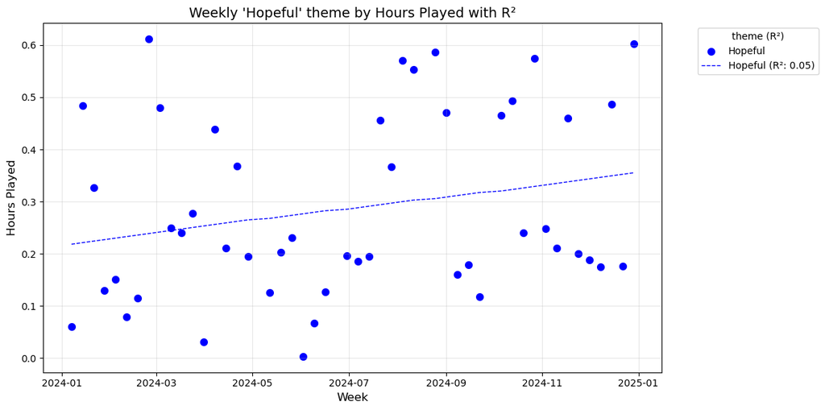

```python
from scipy.stats import linregress
import numpy as np




# Filter data to include only 'hopeful' theme
hopeful_data = weekly_data[weekly_data['theme'] == 'Hopeful']

# Prepare the plot
plt.figure(figsize=(12, 6))

# Scatter plot for 'hopeful' theme
plt.scatter(hopeful_data['date'], hopeful_data['ms_played'],
            color='blue', label='Hopeful', s=50)

# Linear regression for the trend line
x = np.arange(len(hopeful_data['date']))  # Use index for regression
y = hopeful_data['ms_played']
slope, intercept, r_value, _, _ = linregress(x, y)
trend_line = slope * x + intercept

# Plot the trend line
plt.plot(hopeful_data['date'], trend_line,
         color='blue', linestyle='--', linewidth=1,
         label=f"Hopeful (R²: {r_value**2:.2f})")

# Add titles and labels
plt.title("Weekly 'Hopeful' theme by Hours Played with R²", fontsize=14)
plt.xlabel("Week", fontsize=12)
plt.ylabel("Hours Played", fontsize=12)
plt.legend(title="theme (R²)", bbox_to_anchor=(1.05, 1), loc='upper left')
plt.grid(alpha=0.3)
plt.tight_layout()
plt.show()
```

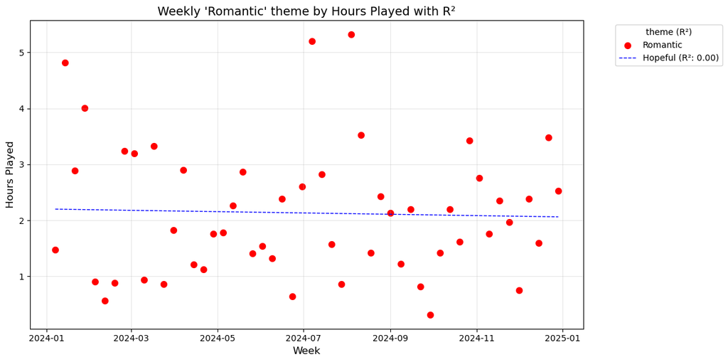

```python
from scipy.stats import linregress
import numpy as np




# Filter data to include only 'hopeful' theme
romantic_data = weekly_data[weekly_data['theme'] == 'Romantic']

# Prepare the plot
plt.figure(figsize=(12, 6))

# Scatter plot for 'hopeful' theme
plt.scatter(romantic_data['date'], romantic_data['ms_played'],
            color='red', label='Romantic', s=50)

# Linear regression for the trend line
x = np.arange(len(romantic_data['date']))  # Use index for regression
y = romantic_data['ms_played']
slope, intercept, r_value, _, _ = linregress(x, y)
trend_line = slope * x + intercept

# Plot the trend line
plt.plot(romantic_data['date'], trend_line,
         color='blue', linestyle='--', linewidth=1,
         label=f"Hopeful (R²: {r_value**2:.2f})")

# Add titles and labels
plt.title("Weekly 'Romantic' theme by Hours Played with R²", fontsize=14)
plt.xlabel("Week", fontsize=12)
plt.ylabel("Hours Played", fontsize=12)
plt.legend(title="theme (R²)", bbox_to_anchor=(1.05, 1), loc='upper left')
plt.grid(alpha=0.3)
plt.tight_layout()
plt.show()
```

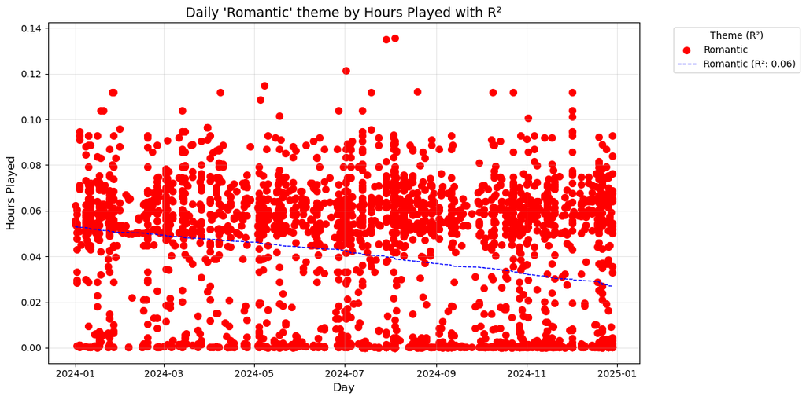

```python
from scipy.stats import linregress

# Isolate 'Romantic' songs at daily grain and convert ms_played → hours
romantic_data_daily = dfAn[dfAn['theme'] == 'Romantic'].copy()
romantic_data_daily['ms_played'] = romantic_data_daily['ms_played'] / 3_600_000

plt.figure(figsize=(12, 6))
plt.scatter(romantic_data_daily['date'], romantic_data_daily['ms_played'],
            color='red', label='Romantic', s=50)

x = np.arange(len(romantic_data_daily['date']))
y = romantic_data_daily['ms_played'].values
slope, intercept, r_value, *_ = linregress(x, y)
trend_line = slope * x + intercept

plt.plot(romantic_data_daily['date'], trend_line,
         color='blue', linestyle='--', linewidth=1,
         label=f"Romantic (R²: {r_value**2:.2f})")

plt.title("Daily 'Romantic' theme by Hours Played with R²", fontsize=14)
plt.xlabel('Day', fontsize=12)
plt.ylabel('Hours Played', fontsize=12)
plt.legend(title='Theme (R²)', bbox_to_anchor=(1.05, 1), loc='upper left')
plt.grid(alpha=0.3)
plt.tight_layout()
plt.show()
```

## 5. Skip Behaviour

Which themes get skipped most? How do skips track against listening volume?

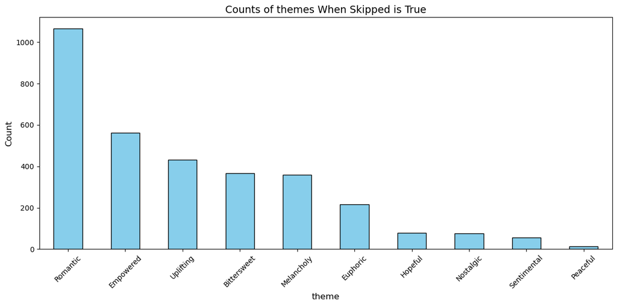

```python
import matplotlib.pyplot as plt

# Filter the data where 'skipped' is True
skipped_data = dfAn[dfAn['skipped'] == True]

# Count occurrences of each theme
theme_counts = skipped_data['theme'].value_counts()

# Create a bar graph
plt.figure(figsize=(12, 6))
theme_counts.plot(kind='bar', color='skyblue', edgecolor='black')

# Add titles and labels
plt.title("Counts of themes When Skipped is True", fontsize=14)
plt.xlabel("theme", fontsize=12)
plt.ylabel("Count", fontsize=12)
plt.xticks(rotation=45, fontsize=10)
plt.tight_layout()

# Display the plot
plt.show()
```

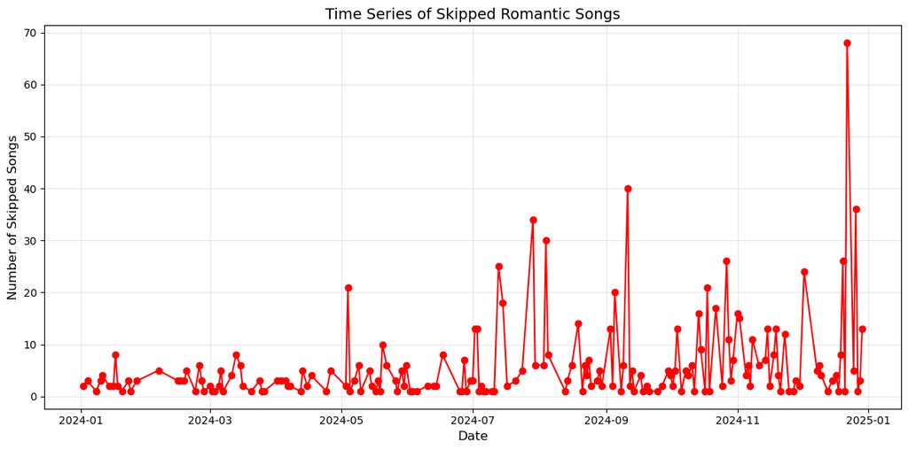

```python
import matplotlib.pyplot as plt

# Filter data for 'Romantic' songs that were skipped
romantic_skipped = dfAn[(dfAn['theme'] == 'Romantic') & (dfAn['skipped'] == True)]

# Group by date and count the number of skipped songs per day
romantic_skipped_counts = romantic_skipped.groupby('date').size()

# Create the time series plot
plt.figure(figsize=(12, 6))
plt.plot(romantic_skipped_counts.index, romantic_skipped_counts.values, marker='o', linestyle='-', color='red')

# Add titles and labels
plt.title("Time Series of Skipped Romantic Songs", fontsize=14)
plt.xlabel("Date", fontsize=12)
plt.ylabel("Number of Skipped Songs", fontsize=12)
plt.grid(alpha=0.3)
plt.tight_layout()

# Display the plot
plt.show()
```

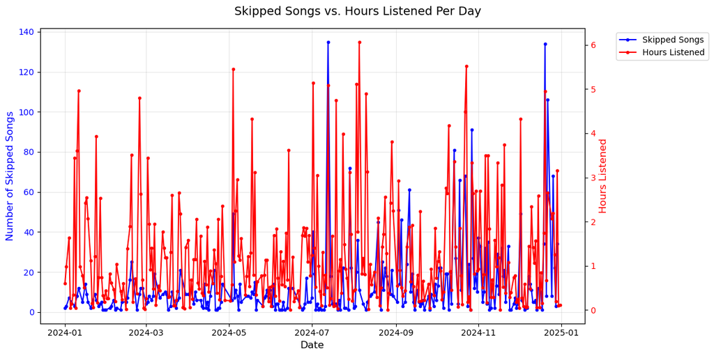

```python
# Group by date and count the number of skipped songs per day
skipped_songs_per_day = skipped_data.groupby('date').size()

# Group by date and sum the hours listened per day
hours_listened_per_day = dfAn.groupby('date')['ms_played'].sum() / 3600000  # Convert ms to hours

# Create the plot
fig, ax1 = plt.subplots(figsize=(12, 6))

# Plot skipped songs on the first Y-axis
ax1.plot(skipped_songs_per_day.index, skipped_songs_per_day.values, marker='.', linestyle='-', color='blue', label='Skipped Songs')
ax1.set_xlabel('Date', fontsize=12)
ax1.set_ylabel('Number of Skipped Songs', fontsize=12, color='blue')
ax1.tick_params(axis='y', labelcolor='blue')

# Create a second Y-axis for hours listened
ax2 = ax1.twinx()
ax2.plot(hours_listened_per_day.index, hours_listened_per_day.values, marker='.', linestyle='-', color='red', label='Hours Listened')
ax2.set_ylabel('Hours Listened', fontsize=12, color='red')
ax2.tick_params(axis='y', labelcolor='red')

# Add titles and grid
fig.suptitle("Skipped Songs vs. Hours Listened Per Day", fontsize=14)
ax1.grid(alpha=0.3)

# Add legends
lines_1, labels_1 = ax1.get_legend_handles_labels()
lines_2, labels_2 = ax2.get_legend_handles_labels()
ax1.legend(lines_1 + lines_2, labels_1 + labels_2, loc='upper left', bbox_to_anchor=(1.05, 1))

plt.tight_layout()
plt.show()
```

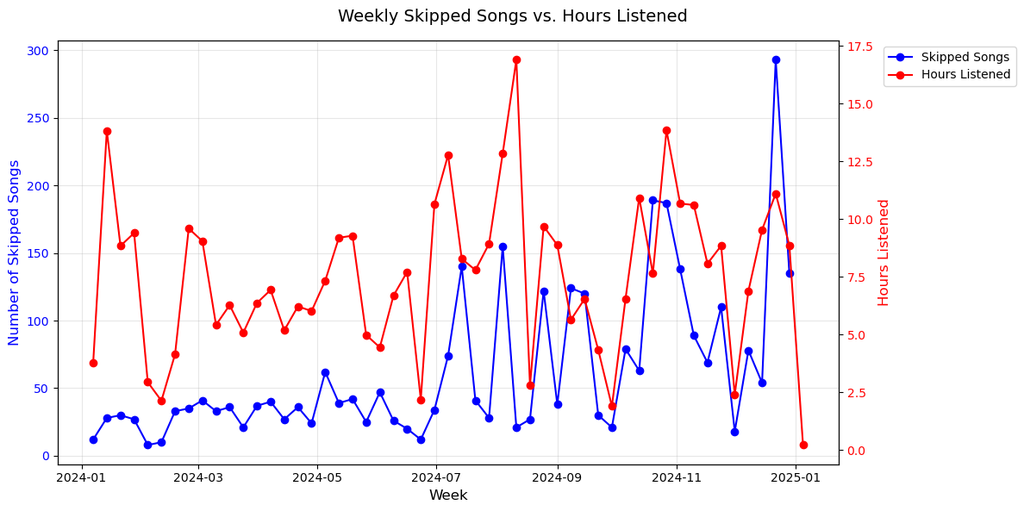

```python
# Group by week and count the number of skipped songs
skipped_songs_per_week = skipped_data.groupby(pd.Grouper(key='date', freq='W')).size()

# Group by week and sum the hours listened
hours_listened_per_week = dfAn.groupby(pd.Grouper(key='date', freq='W'))['ms_played'].sum() / 3600000  # Convert ms to hours

# Create the plot
fig, ax1 = plt.subplots(figsize=(12, 6))

# Plot skipped songs on the first Y-axis
ax1.plot(skipped_songs_per_week.index, skipped_songs_per_week.values, marker='o', linestyle='-', color='blue', label='Skipped Songs')
ax1.set_xlabel('Week', fontsize=12)
ax1.set_ylabel('Number of Skipped Songs', fontsize=12, color='blue')
ax1.tick_params(axis='y', labelcolor='blue')

# Create a second Y-axis for hours listened
ax2 = ax1.twinx()
ax2.plot(hours_listened_per_week.index, hours_listened_per_week.values, marker='o', linestyle='-', color='red', label='Hours Listened')
ax2.set_ylabel('Hours Listened', fontsize=12, color='red')
ax2.tick_params(axis='y', labelcolor='red')

# Add titles and grid
fig.suptitle("Weekly Skipped Songs vs. Hours Listened", fontsize=14)
ax1.grid(alpha=0.3)

# Add legends
lines_1, labels_1 = ax1.get_legend_handles_labels()
lines_2, labels_2 = ax2.get_legend_handles_labels()
ax1.legend(lines_1 + lines_2, labels_1 + labels_2, loc='upper left', bbox_to_anchor=(1.05, 1))

plt.tight_layout()
plt.show()
```

### Skips vs Energy

Is there a relationship between the *energy* of a day's listening and the number of skipped songs?

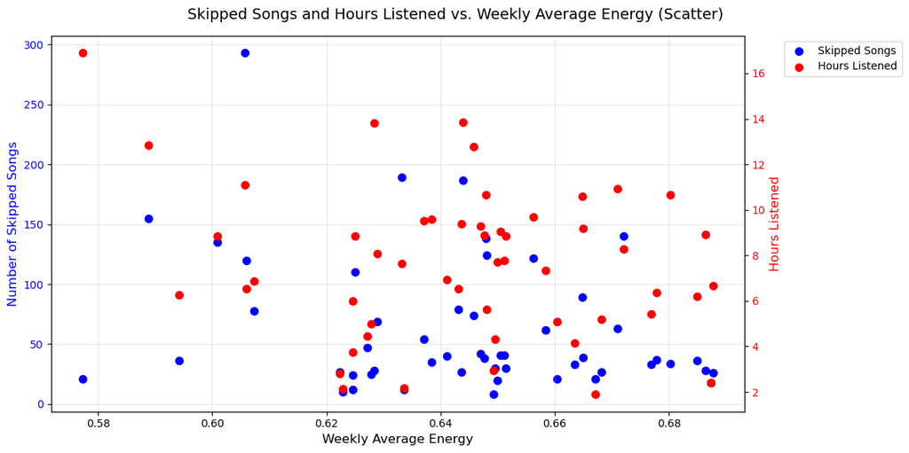

```python
# Group by week and calculate the average energy
average_energy_per_week = dfAn.groupby(pd.Grouper(key='date', freq='W'))['energy'].mean()

# Group by week and count the number of skipped songs
skipped_songs_per_week = skipped_data.groupby(pd.Grouper(key='date', freq='W')).size()

# Group by week and sum the hours listened
hours_listened_per_week = dfAn.groupby(pd.Grouper(key='date', freq='W'))['ms_played'].sum() / 3600000  # Convert ms to hours

# Align all series to the same index
aligned_data = pd.DataFrame({
    'average_energy': average_energy_per_week,
    'skipped_songs': skipped_songs_per_week,
    'hours_listened': hours_listened_per_week
}).dropna()  # Drop rows with missing values to ensure alignment

# Create the plot
fig, ax1 = plt.subplots(figsize=(12, 6))

# Scatter plot for skipped songs on the first Y-axis
ax1.scatter(aligned_data['average_energy'], aligned_data['skipped_songs'], color='blue', label='Skipped Songs', s=50)
ax1.set_xlabel('Weekly Average Energy', fontsize=12)
ax1.set_ylabel('Number of Skipped Songs', fontsize=12, color='blue')
ax1.tick_params(axis='y', labelcolor='blue')

# Create a second Y-axis for hours listened
ax2 = ax1.twinx()
ax2.scatter(aligned_data['average_energy'], aligned_data['hours_listened'], color='red', label='Hours Listened', s=50)
ax2.set_ylabel('Hours Listened', fontsize=12, color='red')
ax2.tick_params(axis='y', labelcolor='red')

# Add titles and grid
fig.suptitle("Skipped Songs and Hours Listened vs. Weekly Average Energy (Scatter)", fontsize=14)
ax1.grid(alpha=0.3)

# Add legends
lines_1, labels_1 = ax1.get_legend_handles_labels()
lines_2, labels_2 = ax2.get_legend_handles_labels()
ax1.legend(lines_1 + lines_2, labels_1 + labels_2, loc='upper left', bbox_to_anchor=(1.05, 1))

plt.tight_layout()
plt.show()
```

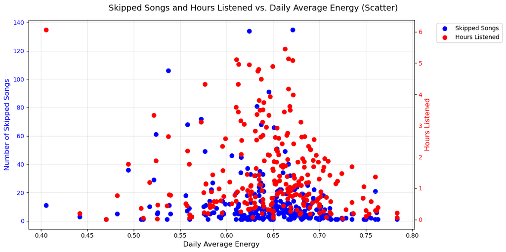

```python
# Group by day and calculate the average energy
average_energy_per_day = dfAn.groupby('date')['energy'].mean()

# Group by day and count the number of skipped songs
skipped_songs_per_day = skipped_data.groupby('date').size()

# Group by day and sum the hours listened
hours_listened_per_day = dfAn.groupby('date')['ms_played'].sum() / 3600000  # Convert ms to hours

# Align all series to the same index
aligned_data_daily = pd.DataFrame({
    'average_energy': average_energy_per_day,
    'skipped_songs': skipped_songs_per_day,
    'hours_listened': hours_listened_per_day
}).dropna()  # Drop rows with missing values to ensure alignment

# Create the plot
fig, ax1 = plt.subplots(figsize=(12, 6))

# Scatter plot for skipped songs on the first Y-axis
ax1.scatter(aligned_data_daily['average_energy'], aligned_data_daily['skipped_songs'], color='blue', label='Skipped Songs', s=50)
ax1.set_xlabel('Daily Average Energy', fontsize=12)
ax1.set_ylabel('Number of Skipped Songs', fontsize=12, color='blue')
ax1.tick_params(axis='y', labelcolor='blue')

# Create a second Y-axis for hours listened
ax2 = ax1.twinx()
ax2.scatter(aligned_data_daily['average_energy'], aligned_data_daily['hours_listened'], color='red', label='Hours Listened', s=50)
ax2.set_ylabel('Hours Listened', fontsize=12, color='red')
ax2.tick_params(axis='y', labelcolor='red')

# Add titles and grid
fig.suptitle("Skipped Songs and Hours Listened vs. Daily Average Energy (Scatter)", fontsize=14)
ax1.grid(alpha=0.3)

# Add legends
lines_1, labels_1 = ax1.get_legend_handles_labels()
lines_2, labels_2 = ax2.get_legend_handles_labels()
ax1.legend(lines_1 + lines_2, labels_1 + labels_2, loc='upper left', bbox_to_anchor=(1.05, 1))

plt.tight_layout()
plt.show()
```

```python
import plotly.express as px
import pandas as pd

# Filter the data where hours listened is greater than 0.05
filtered_data = aligned_data_daily[aligned_data_daily['hours_listened'] > 0.05]

# Ensure 'date' is in the filtered dataset


# Determine the max theme of the day
# Assuming dfAn has columns 'date', 'theme', and 'ms_played'
daily_max_theme = dfAn.groupby('date').apply(lambda x: x.loc[x['ms_played'].idxmax(), 'theme'])

# Add the max theme as a column to the filtered dataset
filtered_data['max_theme'] = filtered_data.index.map(daily_max_theme)

# Create an interactive scatter plot with Plotly
fig = px.scatter(
    filtered_data,
    x='average_energy',
    y='hours_listened',
    color='max_theme',  # Set the color based on the max theme
    hover_data=['date', 'max_theme'],
    title="Filtered Hours Listened vs. Average Energy with Max theme",
    labels={'average_energy': 'Average Energy', 'hours_listened': 'Hours Listened', 'max_theme': 'Max theme'}
)

# Display the interactive plot
fig.update_layout(
    xaxis_title='Average Energy',
    yaxis_title='Hours Listened'
)

# Show the interactive plot
fig.show()
```

[interactive chart not shown]

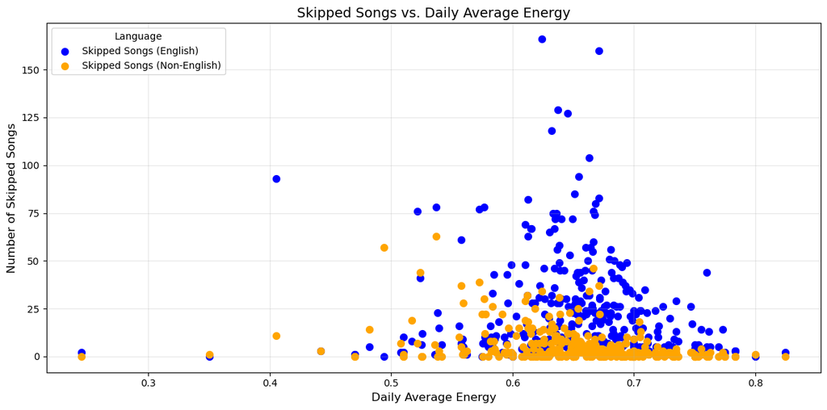

```python
# Group by day and calculate the average energy
average_energy_per_day = dfAn.groupby('date')['energy'].mean()

# Group by day and count the number of skipped songs for English and non-English
skipped_songs_english = dfAn[dfAn['language'] == 'English'].groupby('date').size()
skipped_songs_non_english = dfAn[dfAn['language'] != 'English'].groupby('date').size()

# Align all series to the same index
aligned_data_daily = pd.DataFrame({
    'average_energy': average_energy_per_day,
    'skipped_songs_english': skipped_songs_english,
    'skipped_songs_non_english': skipped_songs_non_english
}).fillna(0)  # Fill missing values with 0 (e.g., no skips on a given day)

# Create the plot
plt.figure(figsize=(12, 6))

# Scatter plot for skipped English songs
plt.scatter(aligned_data_daily['average_energy'], aligned_data_daily['skipped_songs_english'],
            color='blue', s=50, label='Skipped Songs (English)')

# Scatter plot for skipped non-English songs
plt.scatter(aligned_data_daily['average_energy'], aligned_data_daily['skipped_songs_non_english'],
            color='orange', s=50, label='Skipped Songs (Non-English)')

# Add titles and labels
plt.title("Skipped Songs vs. Daily Average Energy", fontsize=14)
plt.xlabel("Daily Average Energy", fontsize=12)
plt.ylabel("Number of Skipped Songs", fontsize=12)
plt.legend(loc='upper left', title="Language")
plt.grid(alpha=0.3)

# Display the plot
plt.tight_layout()
plt.show()
```

### Played vs Skipped Energy

Compare the average energy of songs the user *finished* vs songs they *skipped*. If skipped songs consistently have higher energy, the user tends to skip away from high-energy tracks (or vice-versa).

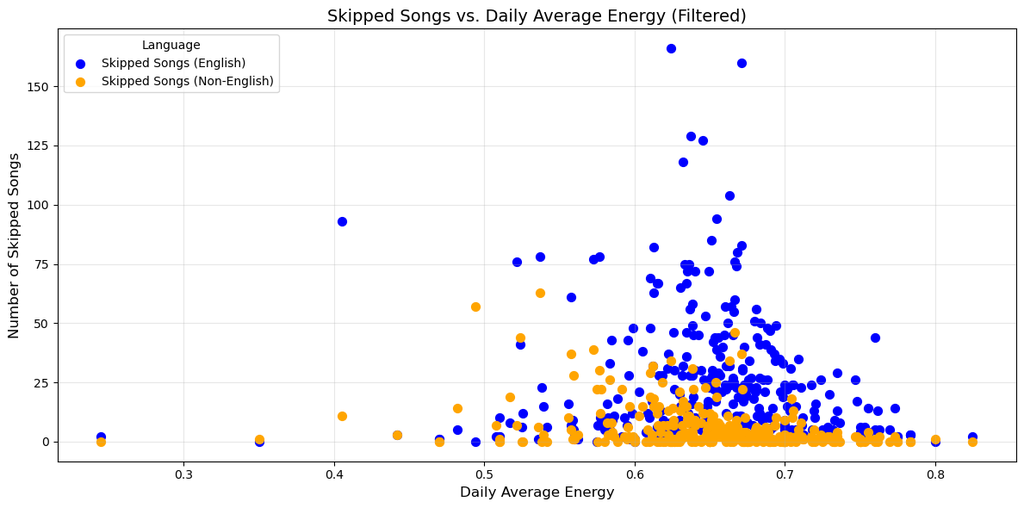

```python
# Group by day and calculate the average energy
average_energy_per_day = dfAn.groupby('date')['energy'].mean()

# Group by day and count the number of skipped songs for English and non-English
skipped_songs_english = dfAn[dfAn['language'] == 'English'].groupby('date').size()
skipped_songs_non_english = dfAn[dfAn['language'] != 'English'].groupby('date').size()

# Align all series to the same index
aligned_data_daily = pd.DataFrame({
    'average_energy': average_energy_per_day,
    'skipped_songs_english': skipped_songs_english,
    'skipped_songs_non_english': skipped_songs_non_english
}).fillna(0)  # Fill missing values with 0

# Filter out rows where skipped songs are 0 for both English and non-English
aligned_data_daily = aligned_data_daily[
    (aligned_data_daily['skipped_songs_english'] > 0) |
    (aligned_data_daily['skipped_songs_non_english'] > 0)
]

# Create the plot
plt.figure(figsize=(12, 6))

# Scatter plot for skipped English songs
plt.scatter(aligned_data_daily['average_energy'], aligned_data_daily['skipped_songs_english'],
            color='blue', s=50, label='Skipped Songs (English)')

# Scatter plot for skipped non-English songs
plt.scatter(aligned_data_daily['average_energy'], aligned_data_daily['skipped_songs_non_english'],
            color='orange', s=50, label='Skipped Songs (Non-English)')

# Add titles and labels
plt.title("Skipped Songs vs. Daily Average Energy (Filtered)", fontsize=14)
plt.xlabel("Daily Average Energy", fontsize=12)
plt.ylabel("Number of Skipped Songs", fontsize=12)
plt.legend(loc='upper left', title="Language")
plt.grid(alpha=0.3)

# Display the plot
plt.tight_layout()
plt.show()
```

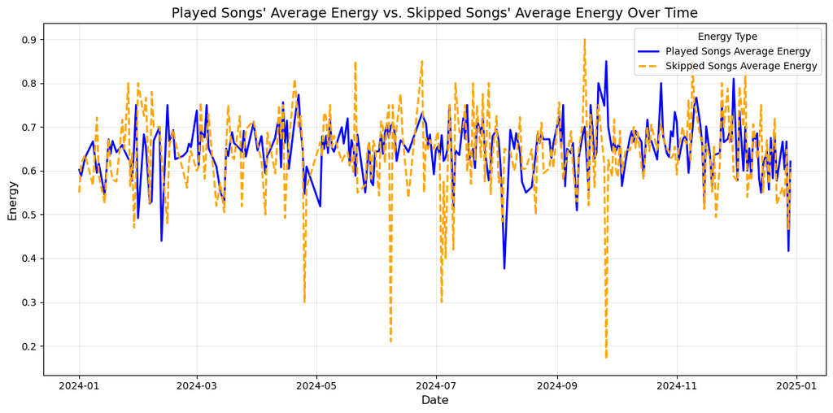

```python
# Calculate daily average energy for played songs (songs not skipped)
played_songs_average_energy = dfAn[dfAn['skipped'] == 0].groupby('date')['energy'].mean()

# Calculate daily average energy for skipped songs only
skipped_songs_average_energy = dfAn[dfAn['skipped'] == 1].groupby('date')['energy'].mean()

# Combine both series into a single DataFrame
energy_data = pd.DataFrame({
    'played_songs_average_energy': played_songs_average_energy,
    'skipped_songs_average_energy': skipped_songs_average_energy
}).dropna()  # Drop days where one of the values is missing

# Plot the data
plt.figure(figsize=(12, 6))

# Plot average energy of played songs
plt.plot(energy_data.index, energy_data['played_songs_average_energy'], label='Played Songs Average Energy', color='blue', linewidth=2)

# Plot average energy of skipped songs
plt.plot(energy_data.index, energy_data['skipped_songs_average_energy'], label='Skipped Songs Average Energy', color='orange', linewidth=2, linestyle='--')

# Add titles and labels
plt.title("Played Songs' Average Energy vs. Skipped Songs' Average Energy Over Time", fontsize=14)
plt.xlabel("Date", fontsize=12)
plt.ylabel("Energy", fontsize=12)
plt.legend(loc='upper right', fontsize=10, title="Energy Type")
plt.grid(alpha=0.3)

# Display the plot
plt.tight_layout()
plt.show()
```

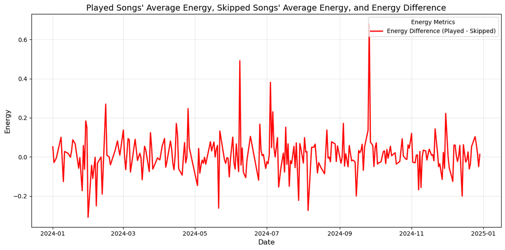

```python
import matplotlib.pyplot as plt
import pandas as pd

plt.figure(figsize=(12, 6))

# Plot average energy of played songs
#plt.plot(energy_data.index, energy_data['played_songs_average_energy'], label='Played Songs Average Energy', color='blue', linewidth=2)


# Plot average energy of skipped songs
#plt.plot(energy_data.index, energy_data['skipped_songs_average_energy'], label='Skipped Songs Average Energy', color='orange', linewidth=2, linestyle='--')

# Plot energy difference
plt.plot(energy_data.index, energy_data['energy_difference'], label='Energy Difference (Played - Skipped)', color='red', linewidth=2, linestyle='-')

# Add titles and labels
plt.title("Played Songs' Average Energy, Skipped Songs' Average Energy, and Energy Difference", fontsize=14)
plt.xlabel("Date", fontsize=12)
plt.ylabel("Energy", fontsize=12)
plt.legend(loc='upper right', fontsize=10, title="Energy Metrics")
plt.grid(alpha=0.3)

# Display the plot
plt.tight_layout()
plt.show()
```

### Statistical Test

One-sample t-test: is the daily gap (played-energy − skipped-energy) significantly greater than 0.01?

```python
from scipy.stats import ttest_1samp
import numpy as np

# Calculate the average energy difference
average_energy_difference = energy_data['energy_difference'].mean()
print(f"Average Energy Difference: {average_energy_difference:.4f}")

# Perform a one-sample t-test to check if the mean > 0.01
t_stat, p_value = ttest_1samp(energy_data['energy_difference'], 0.01)

# Since we are testing if mean > 0.01, adjust the p-value for a one-tailed test
one_tailed_p = p_value / 2 if t_stat > 0 else 1

print(f"T-Statistic: {t_stat:.4f}")
print(f"P-Value (one-tailed): {one_tailed_p:.4f}")

# Interpret the result
if one_tailed_p < 0.05:
    print("The mean energy difference is significantly greater than 0.01.")
else:
    print("The mean energy difference is NOT significantly greater than 0.01.")
```

```
Average Energy Difference: 0.0090
T-Statistic: -0.1522
P-Value (one-tailed): 1.0000
The mean energy difference is NOT significantly greater than 0.01.
```

```python
# Calculate the mode of the energy difference
energy_difference_mode = energy_data['energy_difference'].mode()

# Print the mode
if len(energy_difference_mode) > 0:
    print(f"Mode of Energy Difference: {energy_difference_mode.iloc[0]:.4f}")
else:
    print("No mode found (all values are unique).")
```

```
Mode of Energy Difference: 0.0500
```

## 6. Skip Prediction — Random Forest Iterations

Build a binary classifier for `skipped`. Each cell iterates on the feature set; notes inline explain why features were added or removed.

```python
from sklearn.model_selection import train_test_split
from sklearn.ensemble import RandomForestClassifier
from sklearn.metrics import classification_report, accuracy_score
import pandas as pd

# Group data by date to calculate daily average energy
dfAn['is_english'] = (dfAn['language'] == 'English').astype(int)  # Binary flag for English
average_energy_per_day = dfAn.groupby('date')['energy'].transform('mean')  # Daily average energy

# Add the daily average energy to the DataFrame
dfAn['daily_avg_energy'] = average_energy_per_day

# Ensure 'time' is in proper datetime format
#dfAn['time'] = pd.to_datetime(dfAn['date'].astype(str) + ' ' + dfAn['time'].astype(str))

# Extract hour of the day
dfAn['hour'] = dfAn['time'].dt.hour

# Optional: Add part_of_day
def get_part_of_day(hour):
    if 5 <= hour < 12:
        return 'morning'
    elif 12 <= hour < 17:
        return 'afternoon'
    elif 17 <= hour < 21:
        return 'evening'
    else:
        return 'night'

dfAn['part_of_day'] = dfAn['hour'].apply(get_part_of_day)

# One-hot encode the 'theme' and 'part_of_day' columns
df_encoded = pd.get_dummies(dfAn, columns=['theme', 'part_of_day'], drop_first=True)

# Prepare the dataset
features = ['is_english', 'daily_avg_energy', 'hour'] + [col for col in df_encoded if col.startswith('theme_') or col.startswith('part_of_day_')]
df_encoded = df_encoded.dropna(subset=features + ['skipped'])  # Drop rows with missing values

# Define features and target
X = df_encoded[features]
y = df_encoded['skipped']  # Assuming 'skipped' is 1 if skipped, 0 otherwise

# Split the data into training and testing sets
X_train, X_test, y_train, y_test = train_test_split(X, y, test_size=0.3, random_state=4453)

# Train a Random Forest Classifier
model = RandomForestClassifier(class_weight='balanced', random_state=4276)
model.fit(X_train, y_train)

# Predict on the test set
y_pred = model.predict(X_test)

# Evaluate the model
print("Classification Report:")
print(classification_report(y_test, y_pred))
print(f"Accuracy: {accuracy_score(y_test, y_pred):.2f}")

# Feature Importance (Optional)
feature_importances = model.feature_importances_
for feature, importance in zip(X.columns, feature_importances):
    print(f"Feature: {feature}, Importance: {importance:.2f}")
```

```
Classification Report:
              precision    recall  f1-score   support

       False       0.77      0.76      0.76      1868
        True       0.57      0.58      0.57      1011

    accuracy                           0.70      2879
   macro avg       0.67      0.67      0.67      2879
weighted avg       0.70      0.70      0.70      2879

Accuracy: 0.70
Feature: is_english, Importance: 0.02
Feature: daily_avg_energy, Importance: 0.71
Feature: hour, Importance: 0.17
Feature: theme_Empowered, Importance: 0.01
Feature: theme_Euphoric, Importance: 0.01
Feature: theme_Hopeful, Importance: 0.01
Feature: theme_Melancholy, Importance: 0.01
Feature: theme_Nostalgic, Importance: 0.01
Feature: theme_Peaceful, Importance: 0.00
Feature: theme_Romantic, Importance: 0.01
Feature: theme_Sentimental, Importance: 0.01
Feature: theme_Uplifting, Importance: 0.01
Feature: part_of_day_evening, Importance: 0.01
Feature: part_of_day_morning, Importance: 0.01
Feature: part_of_day_night, Importance: 0.01
```

### Including `ms_played` (leakage demo)

`ms_played` is downstream of the skip decision itself — including it drives accuracy to ~92 % but leaks the label. The next cell removes it.

```python
from sklearn.model_selection import train_test_split
from sklearn.ensemble import RandomForestClassifier
from sklearn.metrics import classification_report, accuracy_score
from sklearn.preprocessing import MinMaxScaler
import pandas as pd

# One-hot encode the 'theme', 'part_of_day', and 'genre' columns
df_encoded = pd.get_dummies(dfAn, columns=['theme', 'part_of_day', 'genre'], drop_first=True)

# Scale 'ms_played'
scaler = MinMaxScaler()
df_encoded['ms_played'] = scaler.fit_transform(df_encoded[['ms_played']])

# Prepare the dataset
features = (
    ['is_english', 'daily_avg_energy', 'hour', 'ms_played'] +
    [col for col in df_encoded if col.startswith('theme_') or col.startswith('part_of_day_') or col.startswith('genre_')]
)

# Drop rows with missing values in the required features and target
df_encoded = df_encoded.dropna(subset=features + ['skipped'])

# Define features and target
X = df_encoded[features]
y = df_encoded['skipped']  # Assuming 'skipped' is 1 if skipped, 0 otherwise

# Split the data into training and testing sets
X_train, X_test, y_train, y_test = train_test_split(X, y, test_size=0.3, random_state=4453)

# Train a Random Forest Classifier
model = RandomForestClassifier(class_weight='balanced', random_state=4276)
model.fit(X_train, y_train)

# Predict on the test set
y_pred = model.predict(X_test)

# Evaluate the model
print("Classification Report:")
print(classification_report(y_test, y_pred))
print(f"Accuracy: {accuracy_score(y_test, y_pred):.2f}")

# Feature Importance
feature_importances = model.feature_importances_
for feature, importance in zip(X.columns, feature_importances):
    print(f"Feature: {feature}, Importance: {importance:.2f}")
```

```
Classification Report:
              precision    recall  f1-score   support

       False       0.92      0.96      0.94      1868
        True       0.91      0.85      0.88      1011

    accuracy                           0.92      2879
   macro avg       0.92      0.90      0.91      2879
weighted avg       0.92      0.92      0.92      2879

Accuracy: 0.92
Feature: is_english, Importance: 0.01
Feature: daily_avg_energy, Importance: 0.08
Feature: hour, Importance: 0.04
Feature: ms_played, Importance: 0.72
Feature: theme_Empowered, Importance: 0.00
Feature: theme_Euphoric, Importance: 0.00
Feature: theme_Hopeful, Importance: 0.00
Feature: theme_Melancholy, Importance: 0.00
Feature: theme_Nostalgic, Importance: 0.00
Feature: theme_Peaceful, Importance: 0.00
Feature: theme_Romantic, Importance: 0.01
Feature: theme_Sentimental, Importance: 0.00
Feature: theme_Uplifting, Importance: 0.00
Feature: part_of_day_evening, Importance: 0.01
Feature: part_of_day_morning, Importance: 0.01
Feature: part_of_day_night, Importance: 0.01
Feature: genre_Acoustic Electronic, Importance: 0.00
Feature: genre_Acoustic Pop, Importance: 0.00
Feature: genre_Acoustic Rock, Importance: 0.00
Feature: genre_Afro-pop, Importance: 0.00
Feature: genre_Afrobeats, Importance: 0.00
Feature: genre_Alternative Hip Hop, Importance: 0.00
Feature: genre_Alternative Metal, Importance: 0.00
Feature: genre_Alternative Pop, Importance: 0.00
Feature: genre_Alternative R&B, Importance: 0.00
Feature: genre_Alternative Rock, Importance: 0.00
Feature: genre_Ambient, Importance: 0.00
Feature: genre_Bass House, Importance: 0.00
Feature: genre_Blues Rock, Importance: 0.00
```

[output cut: 127 more lines]

```
Feature: genre_Ska Punk, Importance: 0.00
Feature: genre_Soul, Importance: 0.00
Feature: genre_Southern Rock, Importance: 0.00
Feature: genre_Synth-Pop, Importance: 0.00
Feature: genre_Synth-pop, Importance: 0.00
Feature: genre_Synthpop, Importance: 0.00
Feature: genre_Synthwave, Importance: 0.00
Feature: genre_Tech House, Importance: 0.00
Feature: genre_Trap, Importance: 0.00
Feature: genre_Trap Hip-Hop, Importance: 0.00
Feature: genre_Trap/Electronic, Importance: 0.00
Feature: genre_Trap/Hip Hop, Importance: 0.00
Feature: genre_Tropical House, Importance: 0.00
Feature: genre_Tropical House / Dance-Pop, Importance: 0.00
Feature: genre_Uplifting Trance, Importance: 0.00
```

```python
#the genre has no effect
#taking out genre as a feature and replacing it with platform
#best RF model
from sklearn.model_selection import train_test_split
from sklearn.ensemble import RandomForestClassifier
from sklearn.metrics import classification_report, accuracy_score
import pandas as pd

# Create the binary flag for English
dfAn['is_english'] = (dfAn['language'] == 'English').astype(int)

# Calculate the daily average energy
average_energy_per_day = dfAn.groupby('date')['energy'].transform('mean')
dfAn['daily_avg_energy'] = average_energy_per_day

# One-hot encode the 'platform' column
df_encoded = pd.get_dummies(dfAn, columns=['platform'], drop_first=True)

# Select the features
features = ['is_english', 'daily_avg_energy', 'hour'] + [col for col in df_encoded if col.startswith('platform_')]

# Drop rows with missing values in the selected features and target
df_encoded = df_encoded.dropna(subset=features + ['skipped'])

# Define features and target
X = df_encoded[features]
y = df_encoded['skipped']  # Assuming 'skipped' is 1 if skipped, 0 otherwise

# Split the data into training and testing sets
X_train, X_test, y_train, y_test = train_test_split(X, y, test_size=0.3, random_state=4453)

# Train a Random Forest Classifier
model = RandomForestClassifier(class_weight='balanced', random_state=4276)
model.fit(X_train, y_train)

# Predict on the test set
y_pred = model.predict(X_test)

# Evaluate the model
print("Classification Report:")
print(classification_report(y_test, y_pred))
print(f"Accuracy: {accuracy_score(y_test, y_pred):.2f}")

# Feature Importance (Optional)
feature_importances = model.feature_importances_
for feature, importance in zip(X.columns, feature_importances):
    print(f"Feature: {feature}, Importance: {importance:.2f}")
```

```
Classification Report:
              precision    recall  f1-score   support

       False       0.82      0.75      0.78      1868
        True       0.60      0.70      0.64      1011

    accuracy                           0.73      2879
   macro avg       0.71      0.72      0.71      2879
weighted avg       0.74      0.73      0.73      2879

Accuracy: 0.73
Feature: is_english, Importance: 0.03
Feature: daily_avg_energy, Importance: 0.66
Feature: hour, Importance: 0.24
Feature: platform_ios, Importance: 0.04
Feature: platform_not_applicable, Importance: 0.01
Feature: platform_osx, Importance: 0.02
```